# Is chooseGCM affected by resolution?

This Rmarkdown is part of the following article:

Esser, L.F., Bailly, D., Lima, M.R., Ré, R. 2024. chooseGCM: a toolkit to select General Circulation Models in R. *In prep*.

## Introduction

chooseGCM is a solution for GCMs selection in Climate Change research. We built this Rmarkdown as a way to test the properties of the methods underlying chooseGCM. Results from each function will be presented side by side with changing resolution, allowing better comparison. Here, we have already downloaded GCMs data.

This Rmarkdown will apply different algorithms implemented in chooseGCM in different resolutions. The aim is to understand if resolution changes will affect the GCMs subset selected by algorithms. We expect that results will not change with resolution, since the increase in resolution is just an interpolation of coarser resolution. As a 30 arcsec resolution will be used, we considered just a local scale due to computational and time limitations. We also restricted the variables used to bio1 and bio12 to restrict variation included with variables selection (see the proper Rmarkdown on the effects of variable selection for more information).

```r
# Install and open CRAN libraries
for(x in c("devtools", "geodata", "terra", "tictoc") ){
  if (!require(x, character.only = TRUE)) {
      install.packages(x, dependencies = TRUE)
      library(x, character.only = TRUE)
  }
}

# Install and open chooseGCM
if (!require("chooseGCM", character.only = TRUE)) {
    devtools::install_github("luizesser/chooseGCM")
    library("chooseGCM", character.only = TRUE)
}

# Install and open caretSDM
if (!require("caretSDM", character.only = TRUE)) {
    devtools::install_github("luizesser/caretSDM")
    library("caretSDM", character.only = TRUE)
}
```

## Preparing data

### Import study_area

For this demonstration, we will use Araucaria angustifolia, the brazilian pine, as a study case. This flagship species is a key species for the Atlantic Rainforest biodiversity hotspot. Species records were obtained from GBIF and cleaned by excluding records from outside the native region and NAs. This set of records was then used to build a shape of accessible area by merging buffers of 500 km around each record.

```r
occ_data <- geodata::sp_occurrence("Araucaria", "angustifolia")
```

```
## 1932 records found
```

```
## 0-300-600-900-1200-1500-1800-1932
## 1932 records downloaded
```

```r
occ_data <- occ_data |>
  dplyr::filter(lon >= -64) |>
  dplyr::filter(lon <= -33) |>
  dplyr::filter(lat <= -19.5) |>
  dplyr::filter(lat >= -33)

study_area <- na.omit(occ_data[,c("lon", "lat")]) |>
  sf::st_as_sf(coords= c(1,2), crs = 4326) |>
  sf::st_transform(crs=sf::st_crs(6933)) |>
  sf::st_buffer(dist = 500000) |>
  sf::st_union()
```

### Download GCMs

To obtain GCMs data, we recommend using `geodata` package, which links directly to the WorldClim 2.1 database. We have previously downloaded GCMs data, but an example code is supplied below.

```r
gcms <- geodata:::.cmods
for (r in c(10, 5, 2.5)) {
  for ( g in gcms ) {
    geodata::cmip6_world(model = g,
                         ssp = "585",
                         time = "2081-2100",
                         var = "bioc",
                         res = r,
                         path = ""
    )
  }
}
```

### Import GCMs

The function `import_gcms` helps the user to import data in the correct way, which is a list of GCMs. Each element of the list is a `SpatRaster` from `terra` package, containing all variables. The list should be named with GCMs names to better plot results.

```r
tictoc::tic()
s10 <- chooseGCM::import_gcms(path = "~/storage/WC_data/WC_data_all_gcms_10/",
                              gcm_names = c("ACCESS-CM2","ACCESS-ESM1-5",
                                            "CanESM5-CanOE","CMCC-ESM2",
                                            "CNRM-CM6-1-HR","CNRM-CM6-1",
                                            "CNRM-ESM2-1","EC-Earth3-Veg",
                                            "EC-Earth3-Veg-LR","FIO-ESM-2-0",
                                            "GISS-E2-1-G","GISS-E2-1-H",
                                            "HadGEM3-GC31-LL","INM-CM5-0",
                                            "INM-CM4-8","IPSL-CM6A-LR",
                                            "MIROC-ES2L","MIROC6",
                                            "MPI-ESM1-2-LR","MPI-ESM1-2-HR",
                                            "MRI-ESM2-0","UKESM1-0-LL"))
tictoc::toc()
```

```
## 0.171 sec elapsed
```

```r
tictoc::tic()
s5 <- chooseGCM::import_gcms(path = "~/storage/WC_data/WC_data_all_gcms_5",
                              gcm_names = c("ACCESS-CM2","ACCESS-ESM1-5",
                                            "CanESM5-CanOE","CMCC-ESM2",
                                            "CNRM-CM6-1-HR","CNRM-CM6-1",
                                            "CNRM-ESM2-1","EC-Earth3-Veg",
                                            "EC-Earth3-Veg-LR","FIO-ESM-2-0",
                                            "GISS-E2-1-G","GISS-E2-1-H",
                                            "HadGEM3-GC31-LL","INM-CM5-0",
                                            "INM-CM4-8","IPSL-CM6A-LR",
                                            "MIROC-ES2L","MIROC6",
                                            "MPI-ESM1-2-LR","MPI-ESM1-2-HR",
                                            "MRI-ESM2-0","UKESM1-0-LL"))
tictoc::toc()
```

```
## 0.12 sec elapsed
```

```r
tictoc::tic()
s25 <- chooseGCM::import_gcms(path = "~/storage/WC_data/WC_data_all_gcms_25",
                              gcm_names = c("ACCESS-CM2","ACCESS-ESM1-5",
                                            "CanESM5-CanOE","CMCC-ESM2",
                                            "CNRM-CM6-1-HR","CNRM-CM6-1",
                                            "CNRM-ESM2-1","EC-Earth3-Veg",
                                            "EC-Earth3-Veg-LR","FIO-ESM-2-0",
                                            "GISS-E2-1-G","GISS-E2-1-H",
                                            "HadGEM3-GC31-LL","INM-CM5-0",
                                            "INM-CM4-8","IPSL-CM6A-LR",
                                            "MIROC-ES2L","MIROC6",
                                            "MPI-ESM1-2-LR","MPI-ESM1-2-HR",
                                            "MRI-ESM2-0","UKESM1-0-LL"))
tictoc::toc()
```

```
## 0.118 sec elapsed
```

```r
tictoc::tic()
s30 <- chooseGCM::import_gcms(path = "~/storage/WC_data/WC_data_all_gcms_30",
                              gcm_names = c("ACCESS-CM2","ACCESS-ESM1-5",
                                            "CanESM5-CanOE","CMCC-ESM2",
                                            "CNRM-CM6-1-HR","CNRM-CM6-1",
                                            "CNRM-ESM2-1","EC-Earth3-Veg",
                                            "EC-Earth3-Veg-LR","FIO-ESM-2-0",
                                            "GISS-E2-1-G","GISS-E2-1-H",
                                            "HadGEM3-GC31-LL","INM-CM5-0",
                                            "INM-CM4-8","IPSL-CM6A-LR",
                                            "MIROC-ES2L","MIROC6",
                                            "MPI-ESM1-2-LR","MPI-ESM1-2-HR",
                                            "MRI-ESM2-0","UKESM1-0-LL"))
tictoc::toc()
```

```
## 0.12 sec elapsed
```

Importing GCMs data into R had an marginal difference in time, despite the big difference in size from different files.

## Applying algorithms

### Hierarchical Clustering selection

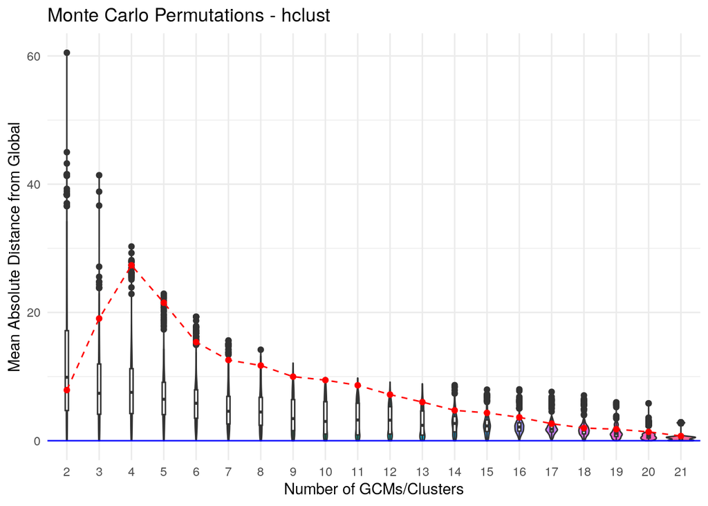

```
##
## $suggested_gcms
## $suggested_gcms$k2
## [1] "ACCESS-ESM1-5"    "EC-Earth3-Veg-LR"
##
## $suggested_gcms$k3
## [1] "ACCESS-ESM1-5"    "EC-Earth3-Veg-LR" "MPI-ESM1-2-HR"
##
## $suggested_gcms$k4
## [1] "ACCESS-ESM1-5"    "CanESM5-CanOE"    "EC-Earth3-Veg-LR" "MPI-ESM1-2-HR"
##
## $suggested_gcms$k5
## [1] "ACCESS-ESM1-5"    "CanESM5-CanOE"    "CMCC-ESM2"        "EC-Earth3-Veg-LR"
## [5] "MPI-ESM1-2-HR"
##
## $suggested_gcms$k6
## [1] "ACCESS-ESM1-5"    "CanESM5-CanOE"    "CMCC-ESM2"        "EC-Earth3-Veg-LR"
## [5] "MPI-ESM1-2-LR"    "MPI-ESM1-2-HR"
##
## $suggested_gcms$k7
## [1] "ACCESS-ESM1-5"    "CanESM5-CanOE"    "CMCC-ESM2"        "INM-CM4-8"
## [5] "EC-Earth3-Veg-LR" "MPI-ESM1-2-LR"    "MPI-ESM1-2-HR"
##
## $suggested_gcms$k8
## [1] "ACCESS-ESM1-5"    "CanESM5-CanOE"    "CMCC-ESM2"        "INM-CM4-8"
## [5] "EC-Earth3-Veg-LR" "GISS-E2-1-H"      "MPI-ESM1-2-LR"    "MPI-ESM1-2-HR"
##
## $suggested_gcms$k9
## [1] "ACCESS-ESM1-5"    "CanESM5-CanOE"    "CMCC-ESM2"        "INM-CM4-8"
## [5] "CNRM-CM6-1-HR"    "EC-Earth3-Veg-LR" "GISS-E2-1-H"      "MPI-ESM1-2-LR"
## [9] "MPI-ESM1-2-HR"
##
## $suggested_gcms$k10
##  [1] "ACCESS-CM2"       "ACCESS-ESM1-5"    "CanESM5-CanOE"    "CMCC-ESM2"
##  [5] "INM-CM4-8"        "CNRM-CM6-1-HR"    "EC-Earth3-Veg-LR" "GISS-E2-1-H"
##  [9] "MPI-ESM1-2-LR"    "MPI-ESM1-2-HR"
##
## $suggested_gcms$k11
##  [1] "ACCESS-CM2"       "ACCESS-ESM1-5"    "CanESM5-CanOE"    "CMCC-ESM2"
##  [5] "INM-CM4-8"        "CNRM-CM6-1-HR"    "EC-Earth3-Veg-LR" "GISS-E2-1-H"
```

[output cut: 51 more lines]

```
##
## $suggested_gcms$k20
##  [1] "ACCESS-CM2"       "ACCESS-ESM1-5"    "CanESM5-CanOE"    "CMCC-ESM2"
##  [5] "CNRM-CM6-1"       "CNRM-CM6-1-HR"    "EC-Earth3-Veg"    "EC-Earth3-Veg-LR"
##  [9] "FIO-ESM-2-0"      "GISS-E2-1-G"      "GISS-E2-1-H"      "HadGEM3-GC31-LL"
## [13] "INM-CM4-8"        "INM-CM5-0"        "IPSL-CM6A-LR"     "MIROC-ES2L"
## [17] "MIROC6"           "MPI-ESM1-2-HR"    "MPI-ESM1-2-LR"    "MRI-ESM2-0"
##
## $suggested_gcms$k21
##  [1] "ACCESS-CM2"       "ACCESS-ESM1-5"    "CanESM5-CanOE"    "CMCC-ESM2"
##  [5] "CNRM-CM6-1"       "CNRM-CM6-1-HR"    "EC-Earth3-Veg"    "EC-Earth3-Veg-LR"
##  [9] "FIO-ESM-2-0"      "GISS-E2-1-G"      "GISS-E2-1-H"      "HadGEM3-GC31-LL"
## [13] "INM-CM4-8"        "INM-CM5-0"        "IPSL-CM6A-LR"     "MIROC-ES2L"
## [17] "MIROC6"           "MPI-ESM1-2-HR"    "MPI-ESM1-2-LR"    "MRI-ESM2-0"
## [21] "UKESM1-0-LL"
```

```r
tictoc::tic("Hierarchical Clustering subset s10")
mc_hclust10 <- montecarlo_gcms(s10,
                             var_names = c("bio1", "bio12"),
                             study_area = study_area,
                             scale = TRUE,
                             perm = 10000,
                             dist_method = "euclidean",
                             clustering_method = "hclust")
mc_hclust10
```

```r
hclust_subset10 <- mc_hclust10$suggested_gcms$k5
tictoc::toc()
```

```
## Hierarchical Clustering subset s10: 14.762 sec elapsed
```

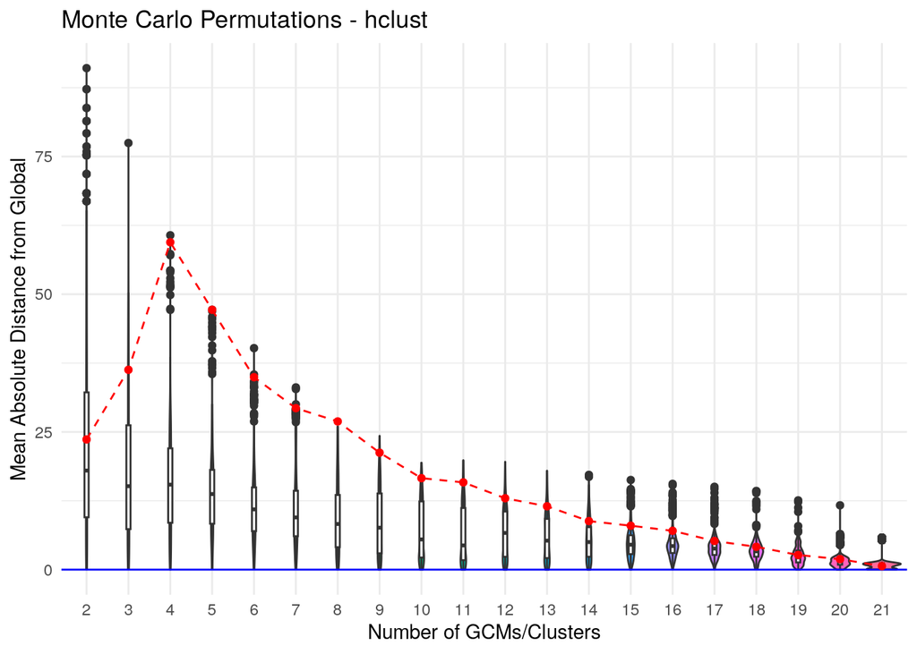

```
##
## $suggested_gcms
## $suggested_gcms$k2
## [1] "FIO-ESM-2-0"      "EC-Earth3-Veg-LR"
##
## $suggested_gcms$k3
## [1] "FIO-ESM-2-0"      "EC-Earth3-Veg-LR" "MPI-ESM1-2-HR"
##
## $suggested_gcms$k4
## [1] "FIO-ESM-2-0"      "CanESM5-CanOE"    "EC-Earth3-Veg-LR" "MPI-ESM1-2-HR"
##
## $suggested_gcms$k5
## [1] "ACCESS-CM2"       "CanESM5-CanOE"    "FIO-ESM-2-0"      "EC-Earth3-Veg-LR"
## [5] "MPI-ESM1-2-HR"
##
## $suggested_gcms$k6
## [1] "ACCESS-CM2"       "CanESM5-CanOE"    "FIO-ESM-2-0"      "EC-Earth3-Veg-LR"
## [5] "MPI-ESM1-2-LR"    "MPI-ESM1-2-HR"
##
## $suggested_gcms$k7
## [1] "ACCESS-CM2"       "CanESM5-CanOE"    "FIO-ESM-2-0"      "CNRM-CM6-1"
## [5] "EC-Earth3-Veg-LR" "MPI-ESM1-2-LR"    "MPI-ESM1-2-HR"
##
## $suggested_gcms$k8
## [1] "ACCESS-CM2"       "CanESM5-CanOE"    "FIO-ESM-2-0"      "CNRM-CM6-1"
## [5] "EC-Earth3-Veg-LR" "GISS-E2-1-H"      "MPI-ESM1-2-LR"    "MPI-ESM1-2-HR"
##
## $suggested_gcms$k9
## [1] "ACCESS-CM2"       "CanESM5-CanOE"    "FIO-ESM-2-0"      "CNRM-CM6-1"
## [5] "CNRM-ESM2-1"      "EC-Earth3-Veg-LR" "GISS-E2-1-H"      "MPI-ESM1-2-LR"
## [9] "MPI-ESM1-2-HR"
##
## $suggested_gcms$k10
##  [1] "ACCESS-CM2"       "HadGEM3-GC31-LL"  "CanESM5-CanOE"    "FIO-ESM-2-0"
##  [5] "CNRM-CM6-1"       "CNRM-ESM2-1"      "EC-Earth3-Veg-LR" "GISS-E2-1-H"
##  [9] "MPI-ESM1-2-LR"    "MPI-ESM1-2-HR"
##
## $suggested_gcms$k11
##  [1] "ACCESS-CM2"       "HadGEM3-GC31-LL"  "CanESM5-CanOE"    "FIO-ESM-2-0"
##  [5] "CNRM-CM6-1"       "CNRM-ESM2-1"      "EC-Earth3-Veg-LR" "GISS-E2-1-H"
```

[output cut: 51 more lines]

```
##
## $suggested_gcms$k20
##  [1] "ACCESS-CM2"       "ACCESS-ESM1-5"    "CanESM5-CanOE"    "CMCC-ESM2"
##  [5] "CNRM-CM6-1"       "CNRM-ESM2-1"      "EC-Earth3-Veg"    "EC-Earth3-Veg-LR"
##  [9] "FIO-ESM-2-0"      "GISS-E2-1-G"      "GISS-E2-1-H"      "HadGEM3-GC31-LL"
## [13] "INM-CM4-8"        "INM-CM5-0"        "IPSL-CM6A-LR"     "MIROC-ES2L"
## [17] "MIROC6"           "MPI-ESM1-2-HR"    "MPI-ESM1-2-LR"    "MRI-ESM2-0"
##
## $suggested_gcms$k21
##  [1] "ACCESS-CM2"       "ACCESS-ESM1-5"    "CanESM5-CanOE"    "CMCC-ESM2"
##  [5] "CNRM-CM6-1"       "CNRM-ESM2-1"      "EC-Earth3-Veg"    "EC-Earth3-Veg-LR"
##  [9] "FIO-ESM-2-0"      "GISS-E2-1-G"      "GISS-E2-1-H"      "HadGEM3-GC31-LL"
## [13] "INM-CM4-8"        "INM-CM5-0"        "IPSL-CM6A-LR"     "MIROC-ES2L"
## [17] "MIROC6"           "MPI-ESM1-2-HR"    "MPI-ESM1-2-LR"    "MRI-ESM2-0"
## [21] "UKESM1-0-LL"
```

```r
tictoc::tic("Hierarchical Clustering subset s5")
mc_hclust5 <- montecarlo_gcms(s5,
                             var_names = c("bio1", "bio12"),
                             study_area = study_area,
                             scale = TRUE,
                             perm = 10000,
                             dist_method = "euclidean",
                             clustering_method = "hclust")
mc_hclust5
```

```r
hclust_subset5 <- mc_hclust5$suggested_gcms$k5
tictoc::toc()
```

```
## Hierarchical Clustering subset s5: 27.168 sec elapsed
```

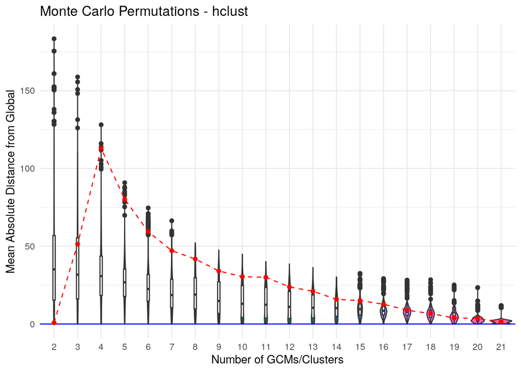

```
##
## $suggested_gcms
## $suggested_gcms$k2
## [1] "FIO-ESM-2-0" "CNRM-ESM2-1"
##
## $suggested_gcms$k3
## [1] "FIO-ESM-2-0"   "CNRM-ESM2-1"   "MPI-ESM1-2-HR"
##
## $suggested_gcms$k4
## [1] "FIO-ESM-2-0"   "CanESM5-CanOE" "CNRM-ESM2-1"   "MPI-ESM1-2-HR"
##
## $suggested_gcms$k5
## [1] "UKESM1-0-LL"   "CanESM5-CanOE" "FIO-ESM-2-0"   "CNRM-ESM2-1"
## [5] "MPI-ESM1-2-HR"
##
## $suggested_gcms$k6
## [1] "UKESM1-0-LL"   "CanESM5-CanOE" "FIO-ESM-2-0"   "CNRM-ESM2-1"
## [5] "MIROC-ES2L"    "MPI-ESM1-2-HR"
##
## $suggested_gcms$k7
## [1] "UKESM1-0-LL"   "CanESM5-CanOE" "FIO-ESM-2-0"   "CNRM-CM6-1"
## [5] "CNRM-ESM2-1"   "MIROC-ES2L"    "MPI-ESM1-2-HR"
##
## $suggested_gcms$k8
## [1] "UKESM1-0-LL"   "CanESM5-CanOE" "FIO-ESM-2-0"   "CNRM-CM6-1"
## [5] "CNRM-ESM2-1"   "GISS-E2-1-G"   "MIROC-ES2L"    "MPI-ESM1-2-HR"
##
## $suggested_gcms$k9
## [1] "UKESM1-0-LL"   "CanESM5-CanOE" "FIO-ESM-2-0"   "CNRM-CM6-1"
## [5] "CNRM-ESM2-1"   "EC-Earth3-Veg" "GISS-E2-1-G"   "MIROC-ES2L"
## [9] "MPI-ESM1-2-HR"
##
## $suggested_gcms$k10
##  [1] "ACCESS-CM2"    "UKESM1-0-LL"   "CanESM5-CanOE" "FIO-ESM-2-0"
##  [5] "CNRM-CM6-1"    "CNRM-ESM2-1"   "EC-Earth3-Veg" "GISS-E2-1-G"
##  [9] "MIROC-ES2L"    "MPI-ESM1-2-HR"
##
## $suggested_gcms$k11
##  [1] "ACCESS-CM2"    "UKESM1-0-LL"   "CanESM5-CanOE" "FIO-ESM-2-0"
##  [5] "CNRM-CM6-1"    "CNRM-ESM2-1"   "EC-Earth3-Veg" "GISS-E2-1-G"
```

[output cut: 51 more lines]

```
##
## $suggested_gcms$k20
##  [1] "ACCESS-CM2"       "ACCESS-ESM1-5"    "CanESM5-CanOE"    "CMCC-ESM2"
##  [5] "CNRM-CM6-1"       "CNRM-ESM2-1"      "EC-Earth3-Veg"    "EC-Earth3-Veg-LR"
##  [9] "FIO-ESM-2-0"      "GISS-E2-1-G"      "GISS-E2-1-H"      "UKESM1-0-LL"
## [13] "INM-CM4-8"        "INM-CM5-0"        "IPSL-CM6A-LR"     "MIROC-ES2L"
## [17] "MIROC6"           "MPI-ESM1-2-HR"    "MPI-ESM1-2-LR"    "MRI-ESM2-0"
##
## $suggested_gcms$k21
##  [1] "ACCESS-CM2"       "ACCESS-ESM1-5"    "CanESM5-CanOE"    "CMCC-ESM2"
##  [5] "CNRM-CM6-1"       "CNRM-ESM2-1"      "EC-Earth3-Veg"    "EC-Earth3-Veg-LR"
##  [9] "FIO-ESM-2-0"      "GISS-E2-1-G"      "GISS-E2-1-H"      "HadGEM3-GC31-LL"
## [13] "INM-CM4-8"        "INM-CM5-0"        "IPSL-CM6A-LR"     "MIROC-ES2L"
## [17] "MIROC6"           "MPI-ESM1-2-HR"    "MPI-ESM1-2-LR"    "MRI-ESM2-0"
## [21] "UKESM1-0-LL"
```

```r
tictoc::tic("Hierarchical Clustering subset s25")
mc_hclust25 <- montecarlo_gcms(s25,
                             var_names = c("bio1", "bio12"),
                             study_area = study_area,
                             scale = TRUE,
                             perm = 10000,
                             dist_method = "euclidean",
                             clustering_method = "hclust")
mc_hclust25
```

```r
hclust_subset25 <- mc_hclust25$suggested_gcms$k5
tictoc::toc()
```

```
## Hierarchical Clustering subset s25: 84.427 sec elapsed
```

```r
tictoc::tic("Hierarchical Clustering subset s30")
mc_hclust30 <- montecarlo_gcms(s30,
                             var_names = c("bio1", "bio12"),
                             study_area = study_area,
                             scale = TRUE,
                             perm = 10000,
                             dist_method = "euclidean",
                             clustering_method = "hclust")
```

[output not shown]

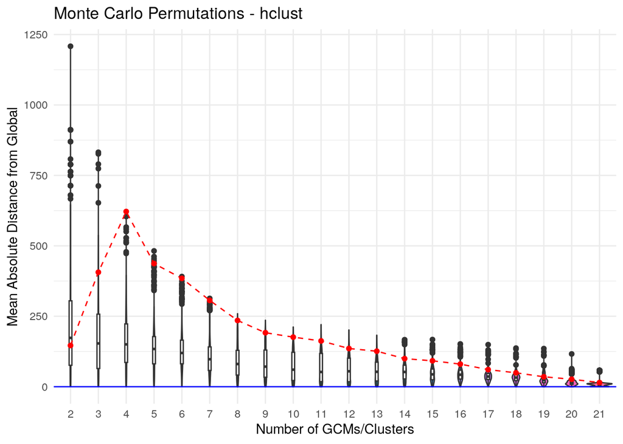

```
##
## $suggested_gcms
## $suggested_gcms$k2
## [1] "ACCESS-CM2"       "EC-Earth3-Veg-LR"
##
## $suggested_gcms$k3
## [1] "ACCESS-CM2"       "EC-Earth3-Veg-LR" "MPI-ESM1-2-HR"
##
## $suggested_gcms$k4
## [1] "ACCESS-CM2"       "CanESM5-CanOE"    "EC-Earth3-Veg-LR" "MPI-ESM1-2-HR"
##
## $suggested_gcms$k5
## [1] "ACCESS-CM2"       "UKESM1-0-LL"      "CanESM5-CanOE"    "EC-Earth3-Veg-LR"
## [5] "MPI-ESM1-2-HR"
##
## $suggested_gcms$k6
## [1] "ACCESS-CM2"       "UKESM1-0-LL"      "CanESM5-CanOE"    "EC-Earth3-Veg-LR"
## [5] "GISS-E2-1-H"      "MPI-ESM1-2-HR"
##
## $suggested_gcms$k7
## [1] "ACCESS-CM2"       "UKESM1-0-LL"      "CanESM5-CanOE"    "CNRM-CM6-1"
## [5] "EC-Earth3-Veg-LR" "GISS-E2-1-H"      "MPI-ESM1-2-HR"
##
## $suggested_gcms$k8
## [1] "ACCESS-CM2"       "UKESM1-0-LL"      "CanESM5-CanOE"    "CNRM-CM6-1"
## [5] "EC-Earth3-Veg-LR" "GISS-E2-1-H"      "MPI-ESM1-2-LR"    "MPI-ESM1-2-HR"
##
## $suggested_gcms$k9
## [1] "ACCESS-CM2"       "UKESM1-0-LL"      "CanESM5-CanOE"    "CNRM-CM6-1"
## [5] "CNRM-CM6-1-HR"    "EC-Earth3-Veg-LR" "GISS-E2-1-H"      "MPI-ESM1-2-LR"
## [9] "MPI-ESM1-2-HR"
##
## $suggested_gcms$k10
##  [1] "ACCESS-CM2"       "UKESM1-0-LL"      "CanESM5-CanOE"    "CMCC-ESM2"
##  [5] "CNRM-CM6-1"       "CNRM-CM6-1-HR"    "EC-Earth3-Veg-LR" "GISS-E2-1-H"
##  [9] "MPI-ESM1-2-LR"    "MPI-ESM1-2-HR"
##
## $suggested_gcms$k11
##  [1] "ACCESS-CM2"       "UKESM1-0-LL"      "CanESM5-CanOE"    "CMCC-ESM2"
##  [5] "CNRM-CM6-1"       "CNRM-CM6-1-HR"    "EC-Earth3-Veg-LR" "GISS-E2-1-H"
```

[output cut: 51 more lines]

```
##
## $suggested_gcms$k20
##  [1] "ACCESS-CM2"       "ACCESS-ESM1-5"    "CanESM5-CanOE"    "CMCC-ESM2"
##  [5] "CNRM-CM6-1"       "CNRM-CM6-1-HR"    "EC-Earth3-Veg"    "EC-Earth3-Veg-LR"
##  [9] "FIO-ESM-2-0"      "GISS-E2-1-G"      "GISS-E2-1-H"      "UKESM1-0-LL"
## [13] "INM-CM4-8"        "INM-CM5-0"        "IPSL-CM6A-LR"     "MIROC-ES2L"
## [17] "MIROC6"           "MPI-ESM1-2-HR"    "MPI-ESM1-2-LR"    "MRI-ESM2-0"
##
## $suggested_gcms$k21
##  [1] "ACCESS-CM2"       "ACCESS-ESM1-5"    "CanESM5-CanOE"    "CMCC-ESM2"
##  [5] "CNRM-CM6-1"       "CNRM-CM6-1-HR"    "EC-Earth3-Veg"    "EC-Earth3-Veg-LR"
##  [9] "FIO-ESM-2-0"      "GISS-E2-1-G"      "GISS-E2-1-H"      "HadGEM3-GC31-LL"
## [13] "INM-CM4-8"        "INM-CM5-0"        "IPSL-CM6A-LR"     "MIROC-ES2L"
## [17] "MIROC6"           "MPI-ESM1-2-HR"    "MPI-ESM1-2-LR"    "MRI-ESM2-0"
## [21] "UKESM1-0-LL"
```

```r
mc_hclust30
```

```r
hclust_subset30 <- mc_hclust30$suggested_gcms$k5
tictoc::toc()
```

```
## Hierarchical Clustering subset s30: 2231.414 sec elapsed
```

### Kmeans selection

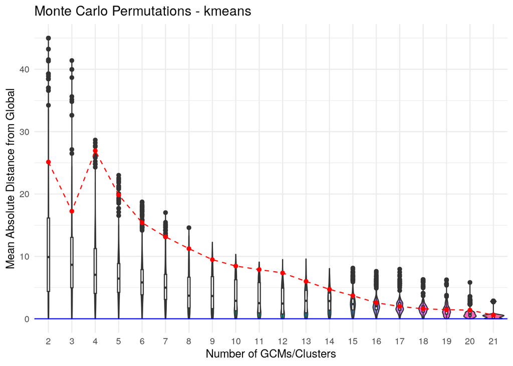

```
##
## $suggested_gcms
## $suggested_gcms$k2
##               1               2
## "CanESM5-CanOE"   "CNRM-ESM2-1"
##
## $suggested_gcms$k3
##               1               2               3
##    "MRI-ESM2-0"   "CNRM-ESM2-1" "CanESM5-CanOE"
##
## $suggested_gcms$k4
##               1               2               3               4
## "MPI-ESM1-2-HR" "CanESM5-CanOE"   "CNRM-ESM2-1"    "MRI-ESM2-0"
##
## $suggested_gcms$k5
##               1               2               3               4               5
## "CanESM5-CanOE"    "MRI-ESM2-0"   "UKESM1-0-LL" "MPI-ESM1-2-HR"    "CNRM-CM6-1"
##
## $suggested_gcms$k6
##               1               2               3               4               5
##     "INM-CM4-8"    "MRI-ESM2-0" "EC-Earth3-Veg" "MPI-ESM1-2-HR" "CanESM5-CanOE"
##               6
##   "UKESM1-0-LL"
##
## $suggested_gcms$k7
##               1               2               3               4               5
##   "UKESM1-0-LL" "MPI-ESM1-2-HR"   "FIO-ESM-2-0" "CanESM5-CanOE"     "INM-CM4-8"
##               6               7
##    "MRI-ESM2-0" "EC-Earth3-Veg"
##
## $suggested_gcms$k8
##               1               2               3               4               5
##   "GISS-E2-1-G"   "FIO-ESM-2-0"    "MIROC-ES2L" "CanESM5-CanOE"   "UKESM1-0-LL"
##               6               7               8
## "EC-Earth3-Veg" "MPI-ESM1-2-HR"     "INM-CM4-8"
##
## $suggested_gcms$k9
##               1               2               3               4               5
##    "MIROC-ES2L"   "UKESM1-0-LL"   "CNRM-ESM2-1"   "GISS-E2-1-G"  "IPSL-CM6A-LR"
##               6               7               8               9
```

[output cut: 104 more lines]

```
##       "MIROC-ES2L"  "HadGEM3-GC31-LL"        "CMCC-ESM2"    "EC-Earth3-Veg"
##
## $suggested_gcms$k21
##                  1                  2                  3                  4
##     "IPSL-CM6A-LR"        "INM-CM4-8"    "MPI-ESM1-2-LR"    "ACCESS-ESM1-5"
##                  5                  6                  7                  8
##           "MIROC6"    "MPI-ESM1-2-HR"    "CNRM-CM6-1-HR" "EC-Earth3-Veg-LR"
##                  9                 10                 11                 12
##    "CanESM5-CanOE"      "FIO-ESM-2-0"      "CNRM-ESM2-1"        "INM-CM5-0"
##                 13                 14                 15                 16
##    "EC-Earth3-Veg"       "ACCESS-CM2"  "HadGEM3-GC31-LL"       "MIROC-ES2L"
##                 17                 18                 19                 20
##       "CNRM-CM6-1"       "MRI-ESM2-0"      "GISS-E2-1-G"        "CMCC-ESM2"
##                 21
##      "GISS-E2-1-H"
```

```r
tictoc::tic("K-means Clustering subset s10")
mc_kmeans10 <- montecarlo_gcms(s10,
                             var_names = c("bio1", "bio12"),
                             study_area = study_area,
                             scale = TRUE,
                             perm = 10000,
                             dist_method = "euclidean",
                             clustering_method = "kmeans")
mc_kmeans10
```

```r
kmeans_subset10 <- mc_kmeans10$suggested_gcms$k5
tictoc::toc()
```

```
## K-means Clustering subset s10: 24.722 sec elapsed
```

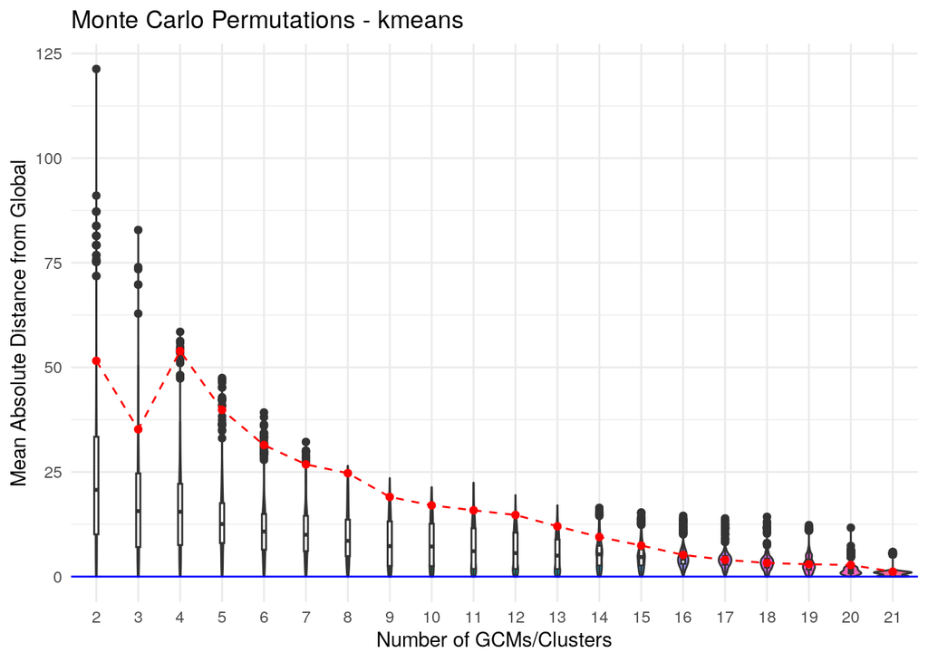

```
##
## $suggested_gcms
## $suggested_gcms$k2
##               1               2
##   "CNRM-ESM2-1" "CanESM5-CanOE"
##
## $suggested_gcms$k3
##               1               2               3
## "CanESM5-CanOE"   "CNRM-ESM2-1"    "MRI-ESM2-0"
##
## $suggested_gcms$k4
##               1               2               3               4
##   "CNRM-ESM2-1" "MPI-ESM1-2-HR"    "MRI-ESM2-0" "CanESM5-CanOE"
##
## $suggested_gcms$k5
##               1               2               3               4               5
##    "CNRM-CM6-1"   "UKESM1-0-LL" "CanESM5-CanOE" "MPI-ESM1-2-HR"    "MRI-ESM2-0"
##
## $suggested_gcms$k6
##               1               2               3               4               5
##    "MRI-ESM2-0" "CanESM5-CanOE"     "INM-CM4-8" "CNRM-CM6-1-HR"   "UKESM1-0-LL"
##               6
## "MPI-ESM1-2-HR"
##
## $suggested_gcms$k7
##               1               2               3               4               5
## "CNRM-CM6-1-HR"   "FIO-ESM-2-0" "MPI-ESM1-2-HR"   "UKESM1-0-LL"     "INM-CM4-8"
##               6               7
##    "MRI-ESM2-0" "CanESM5-CanOE"
##
## $suggested_gcms$k8
##               1               2               3               4               5
##  "IPSL-CM6A-LR" "CanESM5-CanOE" "MPI-ESM1-2-HR"   "GISS-E2-1-G"   "FIO-ESM-2-0"
##               6               7               8
##   "UKESM1-0-LL" "EC-Earth3-Veg"    "MIROC-ES2L"
##
## $suggested_gcms$k9
##               1               2               3               4               5
## "CanESM5-CanOE"    "CNRM-CM6-1"   "GISS-E2-1-G"  "IPSL-CM6A-LR"    "MIROC-ES2L"
##               6               7               8               9
```

[output cut: 104 more lines]

```
##       "ACCESS-CM2"      "GISS-E2-1-G"       "CNRM-CM6-1"      "FIO-ESM-2-0"
##
## $suggested_gcms$k21
##                  1                  2                  3                  4
##    "ACCESS-ESM1-5"    "MPI-ESM1-2-LR"        "CMCC-ESM2"        "INM-CM4-8"
##                  5                  6                  7                  8
##     "IPSL-CM6A-LR"        "INM-CM5-0"    "CanESM5-CanOE"           "MIROC6"
##                  9                 10                 11                 12
##      "GISS-E2-1-G"  "HadGEM3-GC31-LL"    "MPI-ESM1-2-HR"      "CNRM-ESM2-1"
##                 13                 14                 15                 16
##       "MIROC-ES2L"      "GISS-E2-1-H"       "MRI-ESM2-0"       "ACCESS-CM2"
##                 17                 18                 19                 20
##      "FIO-ESM-2-0"       "CNRM-CM6-1"    "EC-Earth3-Veg"    "CNRM-CM6-1-HR"
##                 21
## "EC-Earth3-Veg-LR"
```

```r
tictoc::tic("K-means Clustering subset s5")
mc_kmeans5 <- montecarlo_gcms(s5,
                             var_names = c("bio1", "bio12"),
                             study_area = study_area,
                             scale = TRUE,
                             perm = 10000,
                             dist_method = "euclidean",
                             clustering_method = "kmeans")
mc_kmeans5
```

```r
kmeans_subset5 <- mc_kmeans5$suggested_gcms$k5
tictoc::toc()
```

```
## K-means Clustering subset s5: 34.355 sec elapsed
```

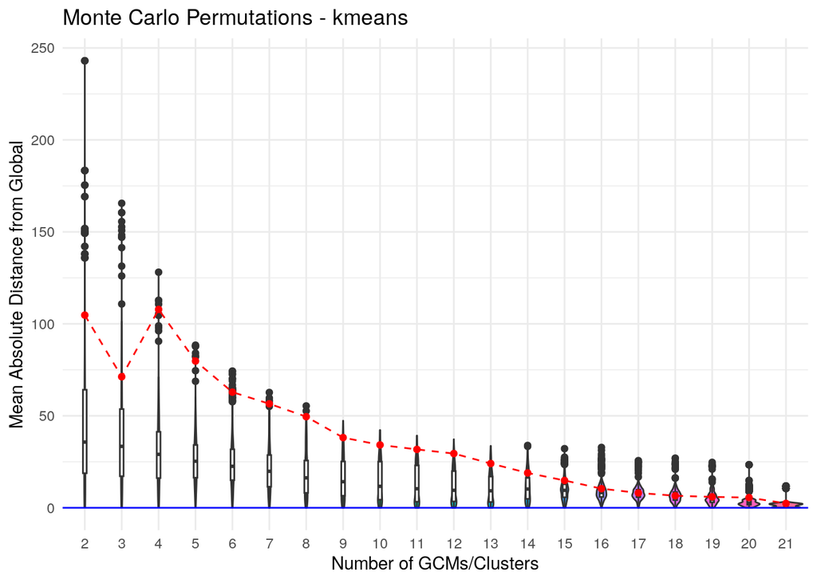

```
##
## $suggested_gcms
## $suggested_gcms$k2
##               1               2
## "CanESM5-CanOE"   "CNRM-ESM2-1"
##
## $suggested_gcms$k3
##               1               2               3
##    "MRI-ESM2-0" "CanESM5-CanOE"   "CNRM-ESM2-1"
##
## $suggested_gcms$k4
##               1               2               3               4
## "CanESM5-CanOE"    "MRI-ESM2-0" "MPI-ESM1-2-HR"   "CNRM-ESM2-1"
##
## $suggested_gcms$k5
##               1               2               3               4               5
## "MPI-ESM1-2-HR"    "CNRM-CM6-1" "CanESM5-CanOE"    "MRI-ESM2-0"   "UKESM1-0-LL"
##
## $suggested_gcms$k6
##               1               2               3               4               5
## "MPI-ESM1-2-HR"     "INM-CM4-8" "CanESM5-CanOE"    "MRI-ESM2-0" "CNRM-CM6-1-HR"
##               6
##   "UKESM1-0-LL"
##
## $suggested_gcms$k7
##               1               2               3               4               5
##    "MRI-ESM2-0"  "IPSL-CM6A-LR" "EC-Earth3-Veg" "CanESM5-CanOE" "MPI-ESM1-2-HR"
##               6               7
##   "UKESM1-0-LL"   "FIO-ESM-2-0"
##
## $suggested_gcms$k8
##               1               2               3               4               5
## "EC-Earth3-Veg"   "GISS-E2-1-G" "MPI-ESM1-2-HR"   "FIO-ESM-2-0"    "MIROC-ES2L"
##               6               7               8
## "CanESM5-CanOE"  "IPSL-CM6A-LR"   "UKESM1-0-LL"
##
## $suggested_gcms$k9
##               1               2               3               4               5
##   "GISS-E2-1-G"   "FIO-ESM-2-0"    "MIROC-ES2L"   "UKESM1-0-LL"    "CNRM-CM6-1"
##               6               7               8               9
```

[output cut: 104 more lines]

```
##      "GISS-E2-1-H"     "IPSL-CM6A-LR"       "ACCESS-CM2"       "CNRM-CM6-1"
##
## $suggested_gcms$k21
##                  1                  2                  3                  4
##    "ACCESS-ESM1-5"      "GISS-E2-1-H"           "MIROC6"    "CNRM-CM6-1-HR"
##                  5                  6                  7                  8
##      "GISS-E2-1-G"       "ACCESS-CM2"     "IPSL-CM6A-LR"        "CMCC-ESM2"
##                  9                 10                 11                 12
##        "INM-CM4-8"    "MPI-ESM1-2-LR" "EC-Earth3-Veg-LR"  "HadGEM3-GC31-LL"
##                 13                 14                 15                 16
##        "INM-CM5-0"    "MPI-ESM1-2-HR"    "EC-Earth3-Veg"    "CanESM5-CanOE"
##                 17                 18                 19                 20
##       "CNRM-CM6-1"       "MRI-ESM2-0"      "FIO-ESM-2-0"       "MIROC-ES2L"
##                 21
##      "CNRM-ESM2-1"
```

```r
tictoc::tic("K-means Clustering subset s25")
mc_kmeans25 <- montecarlo_gcms(s25,
                             var_names = c("bio1", "bio12"),
                             study_area = study_area,
                             scale = TRUE,
                             perm = 10000,
                             dist_method = "euclidean",
                             clustering_method = "kmeans")
mc_kmeans25
```

```r
kmeans_subset25 <- mc_kmeans25$suggested_gcms$k5
tictoc::toc()
```

```
## K-means Clustering subset s25: 85.223 sec elapsed
```

```r
tictoc::tic("K-means Clustering subset s30")
mc_kmeans30 <- montecarlo_gcms(s30,
                             var_names = c("bio1", "bio12"),
                             study_area = study_area,
                             scale = TRUE,
                             perm = 10000,
                             dist_method = "euclidean",
                             clustering_method = "kmeans")
```

[output not shown]

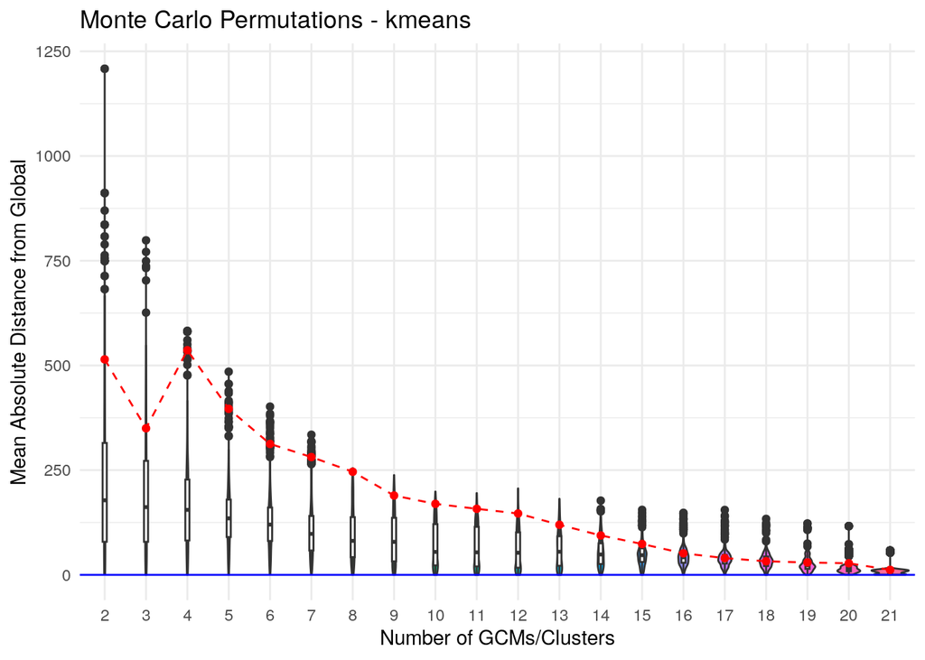

```
##
## $suggested_gcms
## $suggested_gcms$k2
##               1               2
## "CanESM5-CanOE"   "CNRM-ESM2-1"
##
## $suggested_gcms$k3
##               1               2               3
##    "MRI-ESM2-0"   "CNRM-ESM2-1" "CanESM5-CanOE"
##
## $suggested_gcms$k4
##               1               2               3               4
##   "CNRM-ESM2-1"    "MRI-ESM2-0" "MPI-ESM1-2-HR" "CanESM5-CanOE"
##
## $suggested_gcms$k5
##               1               2               3               4               5
##    "MRI-ESM2-0" "MPI-ESM1-2-HR"    "CNRM-CM6-1"   "UKESM1-0-LL" "CanESM5-CanOE"
##
## $suggested_gcms$k6
##               1               2               3               4               5
##   "UKESM1-0-LL" "CanESM5-CanOE"    "MRI-ESM2-0" "CNRM-CM6-1-HR"     "INM-CM4-8"
##               6
## "MPI-ESM1-2-HR"
##
## $suggested_gcms$k7
##               1               2               3               4               5
##  "IPSL-CM6A-LR"    "MRI-ESM2-0" "EC-Earth3-Veg"   "UKESM1-0-LL" "MPI-ESM1-2-HR"
##               6               7
##   "FIO-ESM-2-0" "CanESM5-CanOE"
##
## $suggested_gcms$k8
##               1               2               3               4               5
## "MPI-ESM1-2-HR"  "IPSL-CM6A-LR" "EC-Earth3-Veg"   "GISS-E2-1-G"   "FIO-ESM-2-0"
##               6               7               8
##   "UKESM1-0-LL" "CanESM5-CanOE"    "MIROC-ES2L"
##
## $suggested_gcms$k9
##               1               2               3               4               5
##   "GISS-E2-1-G"   "UKESM1-0-LL" "CanESM5-CanOE" "MPI-ESM1-2-HR"   "CNRM-ESM2-1"
##               6               7               8               9
```

[output cut: 104 more lines]

```
##        "INM-CM4-8"       "MIROC-ES2L"    "CNRM-CM6-1-HR"      "GISS-E2-1-G"
##
## $suggested_gcms$k21
##                  1                  2                  3                  4
##       "CNRM-CM6-1"  "HadGEM3-GC31-LL"    "MPI-ESM1-2-HR"           "MIROC6"
##                  5                  6                  7                  8
##      "FIO-ESM-2-0"    "CanESM5-CanOE"    "CNRM-CM6-1-HR"      "CNRM-ESM2-1"
##                  9                 10                 11                 12
##     "IPSL-CM6A-LR"      "GISS-E2-1-G" "EC-Earth3-Veg-LR"       "ACCESS-CM2"
##                 13                 14                 15                 16
##       "MIROC-ES2L"    "MPI-ESM1-2-LR"        "INM-CM5-0"    "ACCESS-ESM1-5"
##                 17                 18                 19                 20
##        "INM-CM4-8"        "CMCC-ESM2"       "MRI-ESM2-0"      "GISS-E2-1-H"
##                 21
##    "EC-Earth3-Veg"
```

```r
mc_kmeans30
```

```r
kmeans_subset30 <- mc_kmeans30$suggested_gcms$k5
tictoc::toc()
```

```
## K-means Clustering subset s30: 2232.994 sec elapsed
```

### Closestdist selection

```r
tictoc::tic("Closestdist subset s10")
mc_closestdist10 <- closestdist_gcms(s10,
                             var_names = c("bio1", "bio12"),
                             study_area = study_area,
                             method = "euclidean")
```

```
## CRS from s and study_area are not identical. Reprojecting study area.
```

```r
mc_closestdist10
```

```
## $suggested_gcms
## [1] "CNRM-CM6-1"    "MPI-ESM1-2-HR" "MPI-ESM1-2-LR" "MIROC-ES2L"
## [5] "MIROC6"        "INM-CM5-0"
##
## $best_mean_diff
## [1] 0.0008346833
##
## $global_mean
## [1] 38.9711
```

```r
closestdist_subset10 <- mc_closestdist10$suggested_gcms
tictoc::toc()
```

```
## Closestdist subset s10: 2.935 sec elapsed
```

```r
tictoc::tic("Closestdist subset s5")
mc_closestdist5 <- closestdist_gcms(s5,
                             var_names = c("bio1", "bio12"),
                             study_area = study_area,
                             method = "euclidean")
```

```
## CRS from s and study_area are not identical. Reprojecting study area.
```

```r
mc_closestdist5
```

```
## $suggested_gcms
## [1] "FIO-ESM-2-0"  "MRI-ESM2-0"   "IPSL-CM6A-LR" "GISS-E2-1-H"
##
## $best_mean_diff
## [1] 0.002049127
##
## $global_mean
## [1] 77.77632
```

```r
closestdist_subset5 <- mc_closestdist5$suggested_gcms
tictoc::toc()
```

```
## Closestdist subset s5: 8.157 sec elapsed
```

```r
tictoc::tic("Closestdist subset s25")
mc_closestdist25 <- closestdist_gcms(s25,
                             var_names = c("bio1", "bio12"),
                             study_area = study_area,
                             method = "euclidean")
```

```
## CRS from s and study_area are not identical. Reprojecting study area.
```

```r
mc_closestdist25
```

```
## $suggested_gcms
## [1] "IPSL-CM6A-LR"  "MPI-ESM1-2-HR" "MPI-ESM1-2-LR" "INM-CM5-0"
## [5] "MIROC-ES2L"    "MIROC6"        "CMCC-ESM2"     "ACCESS-ESM1-5"
## [9] "CNRM-CM6-1"
##
## $best_mean_diff
## [1] 0.0004073579
##
## $global_mean
## [1] 155.428
```

```r
closestdist_subset25 <- mc_closestdist25$suggested_gcms
tictoc::toc()
```

```
## Closestdist subset s25: 31.58 sec elapsed
```

```r
tictoc::tic("Closestdist subset s30")
mc_closestdist30 <- closestdist_gcms(s30,
                             var_names = c("bio1", "bio12"),
                             study_area = study_area,
                             method = "euclidean")
```

```
## CRS from s and study_area are not identical. Reprojecting study area.
```

```r
mc_closestdist30
```

```
## $suggested_gcms
## [1] "CanESM5-CanOE" "GISS-E2-1-H"   "INM-CM4-8"     "CNRM-CM6-1"
## [5] "IPSL-CM6A-LR"  "EC-Earth3-Veg" "MPI-ESM1-2-LR" "ACCESS-ESM1-5"
##
## $best_mean_diff
## [1] 0.0212276
##
## $global_mean
## [1] 774.4607
```

```r
closestdist_subset30 <- mc_closestdist30$suggested_gcms
tictoc::toc()
```

```
## Closestdist subset s30: 852.672 sec elapsed
```

### Closestdist selection with fixed k

```r
tictoc::tic("Closestdist3 subset s10")
mc_closestdist310 <- closestdist_gcms(s10,
                             var_names = c("bio1", "bio12"),
                             study_area = study_area,
                             method = "euclidean",
                             k = 3)
```

```
## CRS from s and study_area are not identical. Reprojecting study area.
```

```r
mc_closestdist310
```

```
## $suggested_gcms
## [1] "ACCESS-ESM1-5" "CNRM-CM6-1"    "FIO-ESM-2-0"
##
## $best_mean_diff
## [1] 0.003674818
##
## $global_mean
## [1] 38.9711
```

```r
closestdist3_subset10 <- mc_closestdist310$suggested_gcms
tictoc::toc()
```

```
## Closestdist3 subset s10: 3.013 sec elapsed
```

```r
tictoc::tic("Closestdist3 subset s5")
mc_closestdist35 <- closestdist_gcms(s5,
                             var_names = c("bio1", "bio12"),
                             study_area = study_area,
                             method = "euclidean",
                             k = 3)
```

```
## CRS from s and study_area are not identical. Reprojecting study area.
```

```r
mc_closestdist35
```

```
## $suggested_gcms
## [1] "CMCC-ESM2"        "CNRM-CM6-1"       "EC-Earth3-Veg-LR"
##
## $best_mean_diff
## [1] 0.01299014
##
## $global_mean
## [1] 77.77632
```

```r
closestdist3_subset5 <- mc_closestdist35$suggested_gcms
tictoc::toc()
```

```
## Closestdist3 subset s5: 8.655 sec elapsed
```

```r
tictoc::tic("Closestdist3 subset s25")
mc_closestdist325 <- closestdist_gcms(s25,
                             var_names = c("bio1", "bio12"),
                             study_area = study_area,
                             method = "euclidean",
                             k = 3)
```

```
## CRS from s and study_area are not identical. Reprojecting study area.
```

```r
mc_closestdist325
```

```
## $suggested_gcms
## [1] "CNRM-CM6-1"  "FIO-ESM-2-0" "MIROC-ES2L"
##
## $best_mean_diff
## [1] 0.1357029
##
## $global_mean
## [1] 155.428
```

```r
closestdist3_subset25 <- mc_closestdist325$suggested_gcms
tictoc::toc()
```

```
## Closestdist3 subset s25: 30.279 sec elapsed
```

```r
tictoc::tic("Closestdist3 subset s30")
mc_closestdist330 <- closestdist_gcms(s30,
                             var_names = c("bio1", "bio12"),
                             study_area = study_area,
                             method = "euclidean",
                             k = 3)
```

```
## CRS from s and study_area are not identical. Reprojecting study area.
```

```r
mc_closestdist330
```

```
## $suggested_gcms
## [1] "FIO-ESM-2-0"  "INM-CM5-0"    "IPSL-CM6A-LR"
##
## $best_mean_diff
## [1] 0.2348406
##
## $global_mean
## [1] 774.4607
```

```r
closestdist3_subset30 <- mc_closestdist330$suggested_gcms
tictoc::toc()
```

```
## Closestdist3 subset s30: 841.433 sec elapsed
```

## Results

```r
table(c(hclust_subset10, hclust_subset5, hclust_subset25, hclust_subset30))
```

```
##
##       ACCESS-CM2    ACCESS-ESM1-5    CanESM5-CanOE        CMCC-ESM2
##                2                1                4                1
##      CNRM-ESM2-1 EC-Earth3-Veg-LR      FIO-ESM-2-0    MPI-ESM1-2-HR
##                1                3                2                4
##      UKESM1-0-LL
##                2
```

```r
table(c(kmeans_subset10, kmeans_subset5, kmeans_subset25, kmeans_subset30))
```

```
##
## CanESM5-CanOE    CNRM-CM6-1 MPI-ESM1-2-HR    MRI-ESM2-0   UKESM1-0-LL
##             4             4             4             4             4
```

```r
table(c(closestdist_subset10, closestdist_subset5, closestdist_subset25, closestdist_subset30))
```

```
##
## ACCESS-ESM1-5 CanESM5-CanOE     CMCC-ESM2    CNRM-CM6-1 EC-Earth3-Veg
##             2             1             1             3             1
##   FIO-ESM-2-0   GISS-E2-1-H     INM-CM4-8     INM-CM5-0  IPSL-CM6A-LR
##             1             2             1             2             3
##    MIROC-ES2L        MIROC6 MPI-ESM1-2-HR MPI-ESM1-2-LR    MRI-ESM2-0
##             2             2             2             3             1
```

```r
table(c(closestdist3_subset10, closestdist3_subset5, closestdist3_subset25, closestdist3_subset30))
```

```
##
##    ACCESS-ESM1-5        CMCC-ESM2       CNRM-CM6-1 EC-Earth3-Veg-LR
##                1                1                3                1
##      FIO-ESM-2-0        INM-CM5-0     IPSL-CM6A-LR       MIROC-ES2L
##                3                1                1                1
```